# Điều chỉnh view trục x và y

Sử dụng phương thức **plt.xlabel()** hay **plt.ylabel()** để đặt tên cho trục x hay trục y. Thì chúng ta có thể tùy chỉnh khác nhau trên các trục này, sử dụng phương thức **plt.xticks()** để thực hiện thay đổi trục x và **plt.yticks()** để thực hiện những thay đổi trên trục y.

```python
import matplotlib.pyplot as plt
from matplotlib.ticker import FuncFormatter
import numpy as np
```

**Vẽ một biểu đồ đơn giản:**

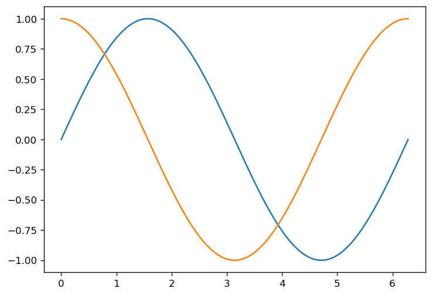

```python
plt.figure( figsize = (7, 5), dpi = 120 )
x = np.linspace(0, 2*np.pi, 1000)
plt.plot(x, np.sin(x))
plt.plot(x, np.cos(x))
# plt.show()
```

**Điều chỉnh trục x và y**

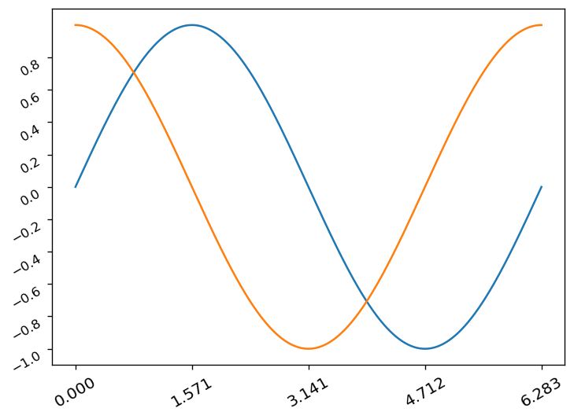

```python
plt.figure( figsize = (7, 5), dpi = 120 )
x = np.linspace(0, 2*np.pi, 1000)
plt.plot(x, np.sin(x))
plt.plot(x, np.cos(x))

# Điều chỉnh trục x và y:
plt.xticks( ticks = np.arange(0, 361/57.2985, 90/57.2985), # 1 rad = 57.2985 degrees
          fontsize = 12,
          rotation = 30,
          ha = 'center',
          va = 'top')
plt.yticks( ticks = np.arange(-1, 1, 0.2), # 1 rad = 57.2985 degrees
          fontsize = 10,
          rotation = 30,
          ha = 'right',
          va = 'top')

plt.show()
```

**Chuyển Radian sang độ:**

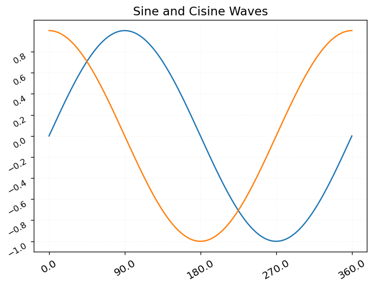

```python
plt.figure( figsize = (7, 5), dpi = 120 )
x = np.linspace(0, 2*np.pi, 1000)
plt.plot(x, np.sin(x))
plt.plot(x, np.cos(x))

plt.xticks( ticks = np.arange(0, 361/57.2985, 90/57.2985), # 1 rad = 57.2985 degrees
          fontsize = 12,
          rotation = 30,
          ha = 'center',
          va = 'top')
plt.yticks( ticks = np.arange(-1, 1, 0.2), # 1 rad = 57.2985 degrees
          fontsize = 10,
          rotation = 30,
          ha = 'right',
          va = 'top')

# Covert Radia sang độ:
def rad_to_degrees(x, pos):
    'coverts radians to degrees'
    return round(x * 57.2985, 2)
formatter = FuncFormatter(rad_to_degrees)
plt.gca().xaxis.set_major_formatter(formatter)

plt.grid(linestyle = '--', linewidth = 0.5, alpha = 0.15)
plt.title('Sine and Cisine Waves', fontsize = 14)
```

**Note:** Ta sử dụng **plt.figure()** để đặt lại kích thước, độ phân giải của biểu đồ và sử dụng **plt.plot()** để vẽ lên biểu đồ.

Phương thức **xticks()** và **yticks()** là tương tự nhau.

- Các tham số : Phương thức này có 2 tham số chính là **ticks** và **label**

  ```
    - ticks : tham số này truyền vào một list các giá trị, các giá trị này chính là các điểm được ghi số trên trục x - hay gọi tắt là number label. Trong ví dụ trên, với  1 radian = 57.2985 độ. như vậy ta sẽ được list các giá trị tương ứng bằng [0.0, 1.57, 3.14, 4.71, 6.28] , hay nó cũng bằng với [0, pi/2, pi, 3*pi/2, 2*pi]

    - label : tham số này là list các nhãn mà bạn muốn đặt thay cho giá trị của ticks ở trên, nếu không có nhãn mặc định là các giá trị của ticks
  ```

Phương thức **plt.gca()** trả về đối tượng Axes hiện tại, tức là biểu đồ hiện tại.

Để vẽ lưới hiển thị dưới nền, sử dụng phương thức **plt.grid()**